# Archived Soil Incubations Manuscript Figures

J. Beem-Miller

14 June 2021

# Results

## Respiration rates

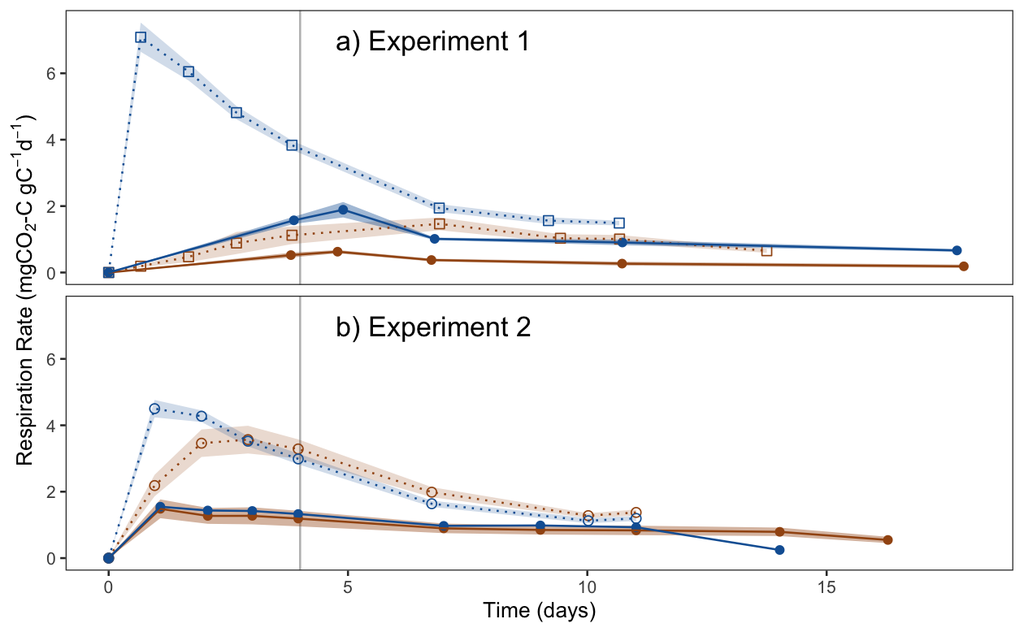

> **Fig. 1. Respiration rates for Experiment 1 (air-dry + storage treatment, 2011) and Experiment 2 (air-dry only treatment, 2019)**

> *Caption:* Top panel shows data from samples collected in 2011 for Experiment 1 (air-dry + storage treatment), bottom panel shows data from samples collected in 2019 for Experiment 2 (air-dry only treatment). Vertical gray line at day 4 demarcates the end of the pre-incubation period and the start of the second enclosure period. Points show measurements and lines show trends in mean respiration rate. Shaded ribbons represent one standard error. The final measurement points for a few samples which took >18 days to reach CO<sub>2</sub> targets are excluded for display reasons; respiration rates for those samples remained flat. Note that headspace CO<sub>2</sub> concentrations for Experiment 1 control samples were only measured once during the pre-incubation period (day 4) in contrast to daily measurements for all other samples. Consequently the respiration rate for those samples is the cumulative average rate over the first 4 d.

## Radiocarbon data

*Pre-incubation versus equilibrium respiration <sup>14</sup>C-CO<sub>2</sub>*

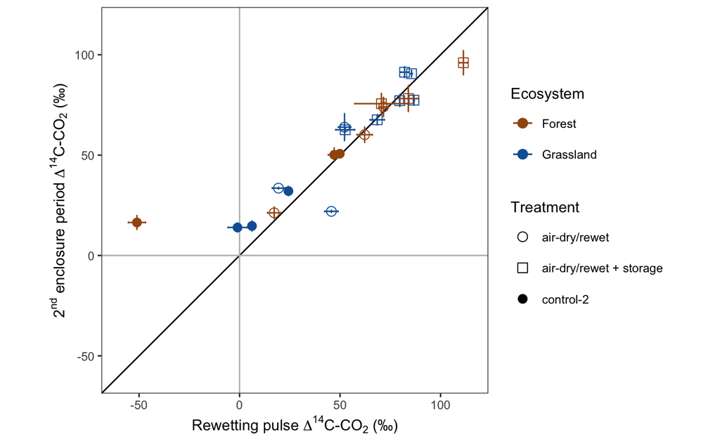

> **Fig. 2. $\Delta$<sup>14</sup>C-CO<sub>2</sub> of the rewetting pulse compared to that of the second enclosure period**

> *Caption:* Points are means of laboratory duplicates and error bars are the min and max. Note that rewetting pulse $\Delta$<sup>14</sup>C was not measured for control-1 samples; additionally samples from three of the forest plots of the air-dry + storage samples from Experiment 1 failed to accumulate enough CO<sub>2</sub> during the pre-incubation period to measure $\Delta$<sup>14</sup>C. The outlier point with the substantially depleted pre-incubation $\Delta$<sup>14</sup>C is from Experiment 2 (control).